# Project: Investigate a Soccer Statistics

## Project Summary

This project will be analysing soccer data that involves players, matches, teams, player and player attributes, countries to answer the following questions.

1. How many matches were played at home and away respectively?
2. What are the different categories of player attributes?
   1. Which was best rating in eacg attribute?
   2. Which was worst rating in each attribute?
   3. Which player(s) has the best rating in eacg attribute?
   4. Which player(s) has the worst rating in each attribute?
3. How old are the players?
   1. How old is the oldest player?
   2. How old is the youngest player?
   3. How many players are below 20 years?
   4. How many players are between 20 and 30 years?
   5. How many players are between 30 and 40 years?
   6. How many players are above 30 years?
4. Goals scored?
   1. What were all the matches that were played at home and how did each team perform?
   2. What were all the matches that were played away and how did each team perform?
   3. How many goals were scored home?
   4. How many goals were scored away?
   5. What was each team's most scored goals for a match?
   6. What was each team's less scored goals for a match?
   7. What team(s) scored more goals?
   8. What team(s) scored less goals?
   9. How many goals(Home and Away) did each team score per season
5. How teams faired against each other
   1. Which teams won home games?
   2. Which teams won away games?
   3. How did the team play against other teams per season?
6. How many and what categories of seasons are there?
7. How many and what categories of stages are there?

```python
# IMPORT PACKAGES
import pandas as pd
import numpy as np
%matplotlib inline
import matplotlib.pyplot as plt
import sqlite3
from datetime import datetime, date
```

```python
# CONNEC TO DATABASE

conn = sqlite3.connect('database.sqlite')
c = conn.cursor()
```

```python
# CREATE CSV'S

df_players = pd.read_sql('SELECT * from Player', conn)
df_teams = pd.read_sql('SELECT * from Team', conn)
df_country = pd.read_sql('SELECT * from Country', conn)
df_league = pd.read_sql('SELECT * from League', conn)
```

```python
#  SAVE TO CSV
df_players.to_csv('players.csv', index=False)
df_teams.to_csv('teams.csv', index=False)
df_country.to_csv('countries.csv', index=False)
df_league.to_csv('leagues.csv', index=False)
```

```python
# LOAD DATA

df_all_players = pd.read_csv('players.csv')
df_all_teams = pd.read_csv('teams.csv')
df_all_country = pd.read_csv('countries.csv')
df_all_league = pd.read_csv('leagues.csv')
```

```python
print(df_all_players.describe())
df_all_players.head()
```

```
                 id  player_api_id  player_fifa_api_id        height  \
count  11060.000000   11060.000000        11060.000000  11060.000000
mean    5537.511392  156582.427215       165664.910488    181.867445
std     3197.692647  160713.700624        58649.928360      6.369201
min        1.000000    2625.000000            2.000000    157.480000
25%     2767.750000   35555.500000       151889.500000    177.800000
50%     5536.500000   96619.500000       184671.000000    182.880000
75%     8306.250000  212470.500000       203883.250000    185.420000
max    11075.000000  750584.000000       234141.000000    208.280000

             weight
count  11060.000000
mean     168.380289
std       14.990217
min      117.000000
25%      159.000000
50%      168.000000
75%      179.000000
max      243.000000
```

|  | id | player_api_id | player_name | player_fifa_api_id | birthday | height | weight |
| --- | --- | --- | --- | --- | --- | --- | --- |
| 0 | 1 | 505942 | Aaron Appindangoye | 218353 | 1992-02-29 00:00:00 | 182.88 | 187 |
| 1 | 2 | 155782 | Aaron Cresswell | 189615 | 1989-12-15 00:00:00 | 170.18 | 146 |
| 2 | 3 | 162549 | Aaron Doran | 186170 | 1991-05-13 00:00:00 | 170.18 | 163 |
| 3 | 4 | 30572 | Aaron Galindo | 140161 | 1982-05-08 00:00:00 | 182.88 | 198 |
| 4 | 5 | 23780 | Aaron Hughes | 17725 | 1979-11-08 00:00:00 | 182.88 | 154 |

```python
df_all_teams.head()
```

|  | id | team_api_id | team_fifa_api_id | team_long_name | team_short_name |
| --- | --- | --- | --- | --- | --- |
| 0 | 1 | 9987 | 673.0 | KRC Genk | GEN |
| 1 | 2 | 9993 | 675.0 | Beerschot AC | BAC |
| 2 | 3 | 10000 | 15005.0 | SV Zulte-Waregem | ZUL |
| 3 | 4 | 9994 | 2007.0 | Sporting Lokeren | LOK |
| 4 | 5 | 9984 | 1750.0 | KSV Cercle Brugge | CEB |

```python
df_all_country.head()
```

|  | id | name |
| --- | --- | --- |
| 0 | 1 | Belgium |
| 1 | 1729 | England |
| 2 | 4769 | France |
| 3 | 7809 | Germany |
| 4 | 10257 | Italy |

```python
df_all_league.head()
```

|  | id | country_id | name |
| --- | --- | --- | --- |
| 0 | 1 | 1 | Belgium Jupiler League |
| 1 | 1729 | 1729 | England Premier League |
| 2 | 4769 | 4769 | France Ligue 1 |
| 3 | 7809 | 7809 | Germany 1. Bundesliga |
| 4 | 10257 | 10257 | Italy Serie A |

```python
# Country Leagues
df_country_league = pd.read_sql(f"SELECT League.name, Country.name FROM League LEFT JOIN Country ON League.country_id = Country.id WHERE League.country_id != ''", conn)
df_country_league.to_csv('countryleague.csv', index=False)

df_leaguee = pd.read_csv('countryleague.csv')
df_leaguee.columns = ['league_name', 'country']
df_leaguee.head()
```

|  | league_name | country |
| --- | --- | --- |
| 0 | Belgium Jupiler League | Belgium |
| 1 | England Premier League | England |
| 2 | France Ligue 1 | France |
| 3 | Germany 1. Bundesliga | Germany |
| 4 | Italy Serie A | Italy |

```python
#  TEAMS DATA

df_teams_info = pd.read_sql(f"SELECT * FROM Team LEFT JOIN Team_Attributes ON Team.team_api_id = Team_Attributes.team_api_id WHERE Team.team_api_id != ''", conn)
df_teams_info.to_csv('teams_info.csv', index=False)

df_teams_info = pd.read_csv('teams_info.csv')
df_teams_info.head()
```

|  | id | team_api_id | team_fifa_api_id | team_long_name | team_short_name | id.1 | team_fifa_api_id.1 | team_api_id.1 | date | buildUpPlaySpeed | ... | chanceCreationShooting | chanceCreationShootingClass | chanceCreationPositioningClass | defencePressure | defencePressureClass | defenceAggression | defenceAggressionClass | defenceTeamWidth | defenceTeamWidthClass | defenceDefenderLineClass |
| --- | --- | --- | --- | --- | --- | --- | --- | --- | --- | --- | --- | --- | --- | --- | --- | --- | --- | --- | --- | --- | --- |
| 0 | 1 | 9987 | 673.0 | KRC Genk | GEN | 485.0 | 673.0 | 9987.0 | 2010-02-22 00:00:00 | 45.0 | ... | 60.0 | Normal | Organised | 70.0 | High | 65.0 | Press | 70.0 | Wide | Cover |
| 1 | 1 | 9987 | 673.0 | KRC Genk | GEN | 486.0 | 673.0 | 9987.0 | 2011-02-22 00:00:00 | 66.0 | ... | 51.0 | Normal | Organised | 48.0 | Medium | 47.0 | Press | 54.0 | Normal | Offside Trap |
| 2 | 1 | 9987 | 673.0 | KRC Genk | GEN | 487.0 | 673.0 | 9987.0 | 2012-02-22 00:00:00 | 53.0 | ... | 56.0 | Normal | Organised | 47.0 | Medium | 45.0 | Press | 55.0 | Normal | Cover |
| 3 | 1 | 9987 | 673.0 | KRC Genk | GEN | 488.0 | 673.0 | 9987.0 | 2013-09-20 00:00:00 | 58.0 | ... | 56.0 | Normal | Organised | 47.0 | Medium | 45.0 | Press | 55.0 | Normal | Cover |
| 4 | 1 | 9987 | 673.0 | KRC Genk | GEN | 489.0 | 673.0 | 9987.0 | 2014-09-19 00:00:00 | 58.0 | ... | 56.0 | Normal | Organised | 47.0 | Medium | 45.0 | Press | 55.0 | Normal | Cover |

5 rows × 30 columns

```python
df_all_players = pd.read_sql(f"SELECT * FROM Player LEFT JOIN Player_Attributes ON Player.player_api_id = Player_Attributes.player_api_id WHERE Player.player_api_id != ''", conn)
df_all_players.to_csv('all_players.csv', index=False)
```

# How many matches were played at home?

```python
# HOME TEAM MATCHES

df_home_matches = pd.read_sql(f"SELECT t.team_long_name as home_team, m.season, m.stage, m.date,  m.home_team_goal  FROM Team t JOIN Match m ON t.team_api_id = m.home_team_api_id", conn)

df_home_matches.to_csv('home_team_matches.csv', index=False)
```

```python
df_home_matches_summary = pd.read_csv('home_team_matches.csv')
df_home_matches_summary.describe()
```

|  | stage | home_team_goal |
| --- | --- | --- |
| count | 25979.000000 | 25979.000000 |
| mean | 18.242773 | 1.544594 |
| std | 10.407354 | 1.297158 |
| min | 1.000000 | 0.000000 |
| 25% | 9.000000 | 1.000000 |
| 50% | 18.000000 | 1.000000 |
| 75% | 27.000000 | 2.000000 |
| max | 38.000000 | 10.000000 |

```python
len(df_home_matches_summary.index)
```

```
25979
```

# How many matches were played at away?

```python
# Aay team matches

df_away_matches = pd.read_sql(f"SELECT t.team_long_name as away_team, m.season, m.stage, m.date,  m.away_team_goal  FROM Team t JOIN Match m ON t.team_api_id = m.away_team_api_id", conn)

df_away_matches.to_csv('away_team_matches.csv', index=False)
```

```python
df_away_matches_summary = pd.read_csv('away_team_matches.csv')
df_away_matches_summary.describe()
```

|  | stage | away_team_goal |
| --- | --- | --- |
| count | 25979.000000 | 25979.000000 |
| mean | 18.242773 | 1.160938 |
| std | 10.407354 | 1.142110 |
| min | 1.000000 | 0.000000 |
| 25% | 9.000000 | 0.000000 |
| 50% | 18.000000 | 1.000000 |
| 75% | 27.000000 | 2.000000 |
| max | 38.000000 | 9.000000 |

```python
len(df_away_matches_summary.index)
```

```
25979
```

```python
# LOAD PLAYERS
df_total_players = pd.read_csv('all_players.csv')
df_total_players.head()
```

|  | id | player_api_id | player_name | player_fifa_api_id | birthday | height | weight | id.1 | player_fifa_api_id.1 | player_api_id.1 | ... | vision | penalties | marking | standing_tackle | sliding_tackle | gk_diving | gk_handling | gk_kicking | gk_positioning | gk_reflexes |
| --- | --- | --- | --- | --- | --- | --- | --- | --- | --- | --- | --- | --- | --- | --- | --- | --- | --- | --- | --- | --- | --- |
| 0 | 1 | 505942 | Aaron Appindangoye | 218353 | 1992-02-29 00:00:00 | 182.88 | 187 | 5 | 218353 | 505942 | ... | 53.0 | 47.0 | 62.0 | 63.0 | 66.0 | 5.0 | 10.0 | 9.0 | 7.0 | 7.0 |
| 1 | 1 | 505942 | Aaron Appindangoye | 218353 | 1992-02-29 00:00:00 | 182.88 | 187 | 4 | 218353 | 505942 | ... | 53.0 | 47.0 | 62.0 | 63.0 | 66.0 | 5.0 | 10.0 | 9.0 | 7.0 | 7.0 |
| 2 | 1 | 505942 | Aaron Appindangoye | 218353 | 1992-02-29 00:00:00 | 182.88 | 187 | 3 | 218353 | 505942 | ... | 54.0 | 48.0 | 65.0 | 66.0 | 69.0 | 6.0 | 11.0 | 10.0 | 8.0 | 8.0 |
| 3 | 1 | 505942 | Aaron Appindangoye | 218353 | 1992-02-29 00:00:00 | 182.88 | 187 | 2 | 218353 | 505942 | ... | 54.0 | 48.0 | 65.0 | 69.0 | 69.0 | 6.0 | 11.0 | 10.0 | 8.0 | 8.0 |
| 4 | 1 | 505942 | Aaron Appindangoye | 218353 | 1992-02-29 00:00:00 | 182.88 | 187 | 1 | 218353 | 505942 | ... | 54.0 | 48.0 | 65.0 | 69.0 | 69.0 | 6.0 | 11.0 | 10.0 | 8.0 | 8.0 |

5 rows × 49 columns

```python
df_away_matches_summary = pd.read_csv('away_team_matches.csv')
df_away_matches_summary .count()
```

```
away_team         25979
season            25979
stage             25979
date              25979
away_team_goal    25979
dtype: int64
```

```python
# remove duplicate columns
df_players_copy = df_total_players.loc[~df_total_players.index.duplicated(),:].copy()

df_players_new = df_players_copy.drop_duplicates(subset=['player_name'], keep='first')

df_players_new.head()
```

|  | id | player_api_id | player_name | player_fifa_api_id | birthday | height | weight | id.1 | player_fifa_api_id.1 | player_api_id.1 | ... | vision | penalties | marking | standing_tackle | sliding_tackle | gk_diving | gk_handling | gk_kicking | gk_positioning | gk_reflexes |
| --- | --- | --- | --- | --- | --- | --- | --- | --- | --- | --- | --- | --- | --- | --- | --- | --- | --- | --- | --- | --- | --- |
| 0 | 1 | 505942 | Aaron Appindangoye | 218353 | 1992-02-29 00:00:00 | 182.88 | 187 | 5 | 218353 | 505942 | ... | 53.0 | 47.0 | 62.0 | 63.0 | 66.0 | 5.0 | 10.0 | 9.0 | 7.0 | 7.0 |
| 5 | 2 | 155782 | Aaron Cresswell | 189615 | 1989-12-15 00:00:00 | 170.18 | 146 | 38 | 189615 | 155782 | ... | 38.0 | 29.0 | 53.0 | 45.0 | 63.0 | 6.0 | 22.0 | 49.0 | 22.0 | 22.0 |
| 38 | 3 | 162549 | Aaron Doran | 186170 | 1991-05-13 00:00:00 | 170.18 | 163 | 64 | 186170 | 162549 | ... | 67.0 | 36.0 | 21.0 | 21.0 | 21.0 | 8.0 | 21.0 | 54.0 | 21.0 | 21.0 |
| 64 | 4 | 30572 | Aaron Galindo | 140161 | 1982-05-08 00:00:00 | 182.88 | 198 | 87 | 140161 | 30572 | ... | 54.0 | 60.0 | 72.0 | 70.0 | 70.0 | 14.0 | 11.0 | 58.0 | 11.0 | 10.0 |
| 87 | 5 | 23780 | Aaron Hughes | 17725 | 1979-11-08 00:00:00 | 182.88 | 154 | 112 | 17725 | 23780 | ... | 60.0 | 81.0 | 74.0 | 79.0 | 77.0 | 12.0 | 11.0 | 55.0 | 10.0 | 6.0 |

5 rows × 49 columns

```python
df_players_categories = df_players_new.drop(df_players_copy.columns[[0, 1, 2, 3, 4,  7, 8, 9, 10,  13, 14, 15]], axis=1)

df_players_new = df_players_new.drop(df_players_copy.columns[[0, 1, 3, 4,  7, 8, 9, 10,  13, 14, 15]], axis=1)

categories = df_players_categories.columns.values.tolist()
categories = np.array(categories)
print(categories)
```

```
['height' 'weight' 'overall_rating' 'potential' 'crossing' 'finishing'
 'heading_accuracy' 'short_passing' 'volleys' 'dribbling' 'curve'
 'free_kick_accuracy' 'long_passing' 'ball_control' 'acceleration'
 'sprint_speed' 'agility' 'reactions' 'balance' 'shot_power' 'jumping'
 'stamina' 'strength' 'long_shots' 'aggression' 'interceptions'
 'positioning' 'vision' 'penalties' 'marking' 'standing_tackle'
 'sliding_tackle' 'gk_diving' 'gk_handling' 'gk_kicking' 'gk_positioning'
 'gk_reflexes']
```

```python
# Max per category
def max_rating(category):
    max_rating_category = df_players_new[category].max()
    print(f"Best rating for category {category} is {max_rating_category}")
    return max_rating_category
```

```python
best_rating = lambda : [max_rating(category) for category in categories]
best_rating()
```

```
Best rating for category height is 208.28
Best rating for category weight is 243
Best rating for category overall_rating is 93.0
Best rating for category potential is 95.0
Best rating for category crossing is 95.0
Best rating for category finishing is 95.0
Best rating for category heading_accuracy is 94.0
Best rating for category short_passing is 94.0
Best rating for category volleys is 91.0
Best rating for category dribbling is 97.0
Best rating for category curve is 92.0
Best rating for category free_kick_accuracy is 94.0
Best rating for category long_passing is 94.0
Best rating for category ball_control is 97.0
Best rating for category acceleration is 96.0
Best rating for category sprint_speed is 96.0
Best rating for category agility is 96.0
Best rating for category reactions is 96.0
Best rating for category balance is 95.0
Best rating for category shot_power is 97.0
Best rating for category jumping is 94.0
Best rating for category stamina is 95.0
Best rating for category strength is 96.0
Best rating for category long_shots is 94.0
Best rating for category aggression is 97.0
Best rating for category interceptions is 96.0
Best rating for category positioning is 95.0
Best rating for category vision is 96.0
Best rating for category penalties is 94.0
Best rating for category marking is 96.0
Best rating for category standing_tackle is 95.0
Best rating for category sliding_tackle is 94.0
Best rating for category gk_diving is 93.0
Best rating for category gk_handling is 93.0
Best rating for category gk_kicking is 94.0
Best rating for category gk_positioning is 96.0
Best rating for category gk_reflexes is 94.0
```

```
[208.28,
 243,
 93.0,
 95.0,
 95.0,
 95.0,
 94.0,
 94.0,
 91.0,
 97.0,
 92.0,
 94.0,
 94.0,
 97.0,
 96.0,
 96.0,
 96.0,
 96.0,
 95.0,
 97.0,
 94.0,
 95.0,
 96.0,
 94.0,
 97.0,
 96.0,
 95.0,
 96.0,
 94.0,
 96.0,
 95.0,
 94.0,
 93.0,
 93.0,
 94.0,
 96.0,
 94.0]
```

### What is the worst rating for each of the player attributes?

```python
# Min per category
def min_rating(category):
    min_rating_category = df_players_new[category].min()
    print(f"Worst rating for category {category} is {min_rating_category}")
    return min_rating_category
```

```python
worst_rating = lambda : [min_rating(category) for category in categories]
worst_rating()
```

```
Worst rating for category height is 157.48
Worst rating for category weight is 117
Worst rating for category overall_rating is 33.0
Worst rating for category potential is 39.0
Worst rating for category crossing is 2.0
Worst rating for category finishing is 1.0
Worst rating for category heading_accuracy is 1.0
Worst rating for category short_passing is 3.0
Worst rating for category volleys is 1.0
Worst rating for category dribbling is 1.0
Worst rating for category curve is 4.0
Worst rating for category free_kick_accuracy is 1.0
Worst rating for category long_passing is 4.0
Worst rating for category ball_control is 5.0
Worst rating for category acceleration is 10.0
Worst rating for category sprint_speed is 13.0
Worst rating for category agility is 15.0
Worst rating for category reactions is 20.0
Worst rating for category balance is 20.0
Worst rating for category shot_power is 2.0
Worst rating for category jumping is 14.0
Worst rating for category stamina is 16.0
Worst rating for category strength is 16.0
Worst rating for category long_shots is 1.0
Worst rating for category aggression is 9.0
Worst rating for category interceptions is 1.0
Worst rating for category positioning is 4.0
Worst rating for category vision is 1.0
Worst rating for category penalties is 3.0
Worst rating for category marking is 1.0
Worst rating for category standing_tackle is 2.0
Worst rating for category sliding_tackle is 2.0
Worst rating for category gk_diving is 1.0
Worst rating for category gk_handling is 1.0
Worst rating for category gk_kicking is 3.0
Worst rating for category gk_positioning is 1.0
Worst rating for category gk_reflexes is 1.0
```

```
[157.48,
 117,
 33.0,
 39.0,
 2.0,
 1.0,
 1.0,
 3.0,
 1.0,
 1.0,
 4.0,
 1.0,
 4.0,
 5.0,
 10.0,
 13.0,
 15.0,
 20.0,
 20.0,
 2.0,
 14.0,
 16.0,
 16.0,
 1.0,
 9.0,
 1.0,
 4.0,
 1.0,
 3.0,
 1.0,
 2.0,
 2.0,
 1.0,
 1.0,
 3.0,
 1.0,
 1.0]
```

### Who is the best player for each category?

```python
# BEST PLAYER
def best_player_category(category):
    best_player = df_players_new[df_players_new[category]== df_players_new[category].max()]
    best_player_names = best_player['player_name']
    print(f"Best player for category {category} is/are {np.array(best_player_names)}")
    return best_player
```

```python
best_player = lambda : [best_player_category(category) for category in categories]
best_player()
```

```
Best player for category height is/are ['Kristof van Hout']
Best player for category weight is/are ['Kristof van Hout' 'Tim Wiese']
Best player for category overall_rating is/are ['Gianluigi Buffon' 'Wayne Rooney']
Best player for category potential is/are ['Ronaldinho']
Best player for category crossing is/are ['David Beckham']
Best player for category finishing is/are ['Luca Toni' 'Thierry Henry']
Best player for category heading_accuracy is/are ['Claudio Pizarro' 'Hernan Crespo' 'Luca Toni']
Best player for category short_passing is/are ['Fabio Liverani' 'Juan Carlos Valeron' 'Juninho Pernambucano,20'
 'Tomas Rosicky']
Best player for category volleys is/are ['Dimitar Berbatov' 'Lukas Podolski']
Best player for category dribbling is/are ['Ronaldinho']
Best player for category curve is/are ['David Beckham']
Best player for category free_kick_accuracy is/are ['Fabio Cannavaro' 'Iker Casillas' 'Paolo Maldini' 'Roy Makaay']
Best player for category long_passing is/are ['David Beckham']
Best player for category ball_control is/are ['Ronaldinho']
Best player for category acceleration is/are ['Arjen Robben' 'Henri Camara' 'Obafemi Martins']
Best player for category sprint_speed is/are ['Ivan Cordoba']
Best player for category agility is/are ['Lionel Messi']
Best player for category reactions is/are ['Arjen Robben']
Best player for category balance is/are ['Aldo Kalulu' 'Joao Costa,21']
Best player for category shot_power is/are ['John Arne Riise']
Best player for category jumping is/are ['Tim Cahill']
Best player for category stamina is/are ['Simone Perrotta']
Best player for category strength is/are ['Daniel van Buyten']
Best player for category long_shots is/are ['Frank Lampard' 'Pavel Nedved' 'Steven Gerrard']
Best player for category aggression is/are ['Martin Demichelis']
Best player for category interceptions is/are ['Timmy Simons']
Best player for category positioning is/are ['Ruud van Nistelrooy']
Best player for category vision is/are ['Xavi Hernandez']
Best player for category penalties is/are ['Adrian Mutu' 'Fabio Cannavaro' 'Iker Casillas' 'Paolo Maldini'
 'Roy Makaay']
Best player for category marking is/are ['Fabio Cannavaro']
Best player for category standing_tackle is/are ['Alessandro Nesta' 'John Terry']
Best player for category sliding_tackle is/are ['Pepe' 'Philipp Lahm']
Best player for category gk_diving is/are ['Gregory Coupet']
Best player for category gk_handling is/are ['Gianluigi Buffon']
Best player for category gk_kicking is/are ['David Beckham']
Best player for category gk_positioning is/are ['Gianluigi Buffon']
Best player for category gk_reflexes is/are ['Petr Cech' 'Sebastian Frey']
```

[output not shown]

[output cut: 522 more lines]

[output not shown]

```python
df_players_new.head()
```

|  | player_name | height | weight | overall_rating | potential | crossing | finishing | heading_accuracy | short_passing | volleys | ... | vision | penalties | marking | standing_tackle | sliding_tackle | gk_diving | gk_handling | gk_kicking | gk_positioning | gk_reflexes |
| --- | --- | --- | --- | --- | --- | --- | --- | --- | --- | --- | --- | --- | --- | --- | --- | --- | --- | --- | --- | --- | --- |
| 0 | Aaron Appindangoye | 182.88 | 187 | 61.0 | 65.0 | 48.0 | 43.0 | 70.0 | 60.0 | 43.0 | ... | 53.0 | 47.0 | 62.0 | 63.0 | 66.0 | 5.0 | 10.0 | 9.0 | 7.0 | 7.0 |
| 5 | Aaron Cresswell | 170.18 | 146 | 53.0 | 60.0 | 22.0 | 48.0 | 52.0 | 39.0 | 30.0 | ... | 38.0 | 29.0 | 53.0 | 45.0 | 63.0 | 6.0 | 22.0 | 49.0 | 22.0 | 22.0 |
| 38 | Aaron Doran | 170.18 | 163 | 59.0 | 70.0 | 63.0 | 69.0 | 45.0 | 53.0 | 63.0 | ... | 67.0 | 36.0 | 21.0 | 21.0 | 21.0 | 8.0 | 21.0 | 54.0 | 21.0 | 21.0 |
| 64 | Aaron Galindo | 182.88 | 198 | 71.0 | 78.0 | 58.0 | 50.0 | 70.0 | 60.0 | 48.0 | ... | 54.0 | 60.0 | 72.0 | 70.0 | 70.0 | 14.0 | 11.0 | 58.0 | 11.0 | 10.0 |
| 87 | Aaron Hughes | 182.88 | 154 | 75.0 | 75.0 | 45.0 | 57.0 | 76.0 | 54.0 | 32.0 | ... | 60.0 | 81.0 | 74.0 | 79.0 | 77.0 | 12.0 | 11.0 | 55.0 | 10.0 | 6.0 |

5 rows × 38 columns

```python
# TOP TEN PLAYERS PER CATEGORY
def plot_best_players_category(category):
    best_ten= df_players_new.nlargest(10,category)
#     print(best_ten)
    best_ten_players = np.array(best_ten['player_name'])
#     print(best_ten_players)
    largest_ten_category = np.array(best_ten[category])
#     print(largest_ten_category)
    print(f"GRAPH FOR best {category}")
    fig, ax = plt.subplots()
    ax.plot(best_ten_players, largest_ten_category, marker='s', lw=2, ms=8, mew=2, mec="navy")
    fig.autofmt_xdate()
    plt.xlabel('Player Name')
    plt.ylabel(f"{category} level")
    plt.title(f"Graph for best {category}")
    plt.show()
```

```
GRAPH FOR best height
```

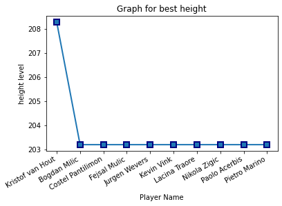

```
GRAPH FOR best weight
```

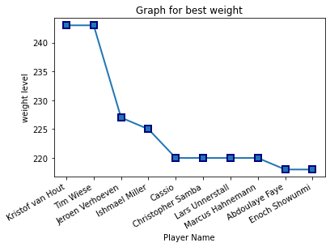

```
GRAPH FOR best overall_rating
```

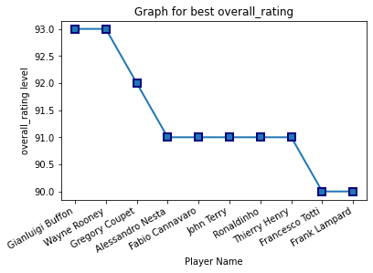

```
GRAPH FOR best potential
```

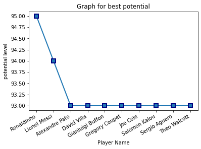

```
GRAPH FOR best crossing
```

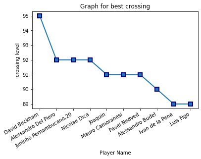

```
GRAPH FOR best finishing
```

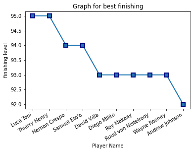

```
GRAPH FOR best heading_accuracy
```

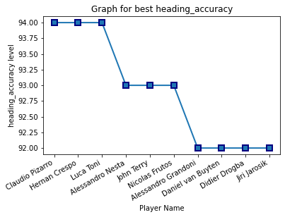

```
GRAPH FOR best short_passing
```

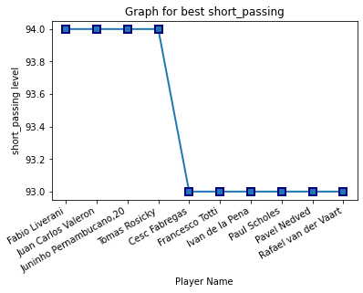

```
GRAPH FOR best volleys
```

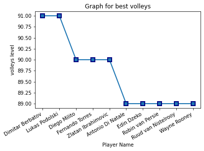

```
GRAPH FOR best dribbling
```

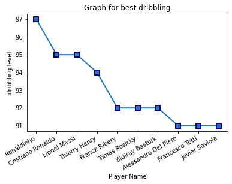

```
GRAPH FOR best curve
```

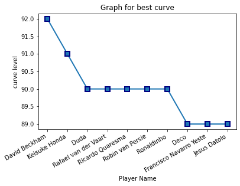

```
GRAPH FOR best free_kick_accuracy
```

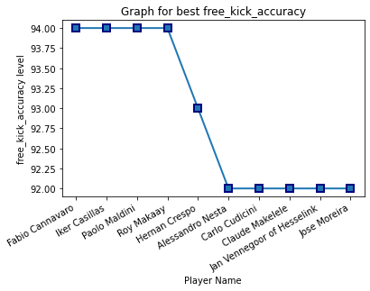

```
GRAPH FOR best long_passing
```

[25 more figures not shown]

[output not shown]

```python
best_player_categories = lambda : [plot_best_players_category(category) for category in categories]
best_player_categories()
```

### Worst player per category

```python
# WORST PLAYER
def worst_player_category(category):
    worst_player = df_players_new[df_players_new[category]== df_players_new[category].min()]
    worst_player_names = worst_player['player_name']
    print(f"Worst player for category {category} is {np.array(worst_player_names)}")
    return worst_player
```

```python
worst_player = lambda : [worst_player_category(category) for category in categories]
worst_player()
```

```
Worst player for category height is ['Juan Quero']
Worst player for category weight is ['Juan Quero']
Worst player for category overall_rating is ['Francesco Della Rocca']
Worst player for category potential is ['Nicola Madonna']
Worst player for category crossing is ['Jakub Szumski' 'Steeve Elana']
Worst player for category finishing is ['Asmir Begovic' 'Nicolas Penneteau' 'Oka Nikolov' 'Raphael Schaefer']
Worst player for category heading_accuracy is ['Jerzy Dudek']
Worst player for category short_passing is ['Alireza Haghighi']
Worst player for category volleys is ['Marian Kello']
Worst player for category dribbling is ['Peterson Pecanha']
Worst player for category curve is ['Gary Woods' 'Jakub Szumski' 'Owain Fon Williams' 'Tommaso Berni']
Worst player for category free_kick_accuracy is ['Wojciech Pawlowski']
Worst player for category long_passing is ['Jakub Slowik']
Worst player for category ball_control is ['Rune Almenning Jarstein']
Worst player for category acceleration is ['Matthew Gilks,18']
Worst player for category sprint_speed is ['Radoslaw Janukiewicz']
Worst player for category agility is ['Connor Ripley']
Worst player for category reactions is ['Joshua Brillante' 'Ulisse Pelloni']
Worst player for category balance is ['Florent Chaigneau' 'Gianluca Pegolo' 'Paulo Lopes' 'Thomas Bosmel']
Worst player for category shot_power is ['Johann Durand']
Worst player for category jumping is ['Alireza Haghighi']
Worst player for category stamina is ['Elisson' 'Giovanaz Assis' 'Landry Bonnefoi' 'Merveille Goblet']
Worst player for category strength is ['Landry Bonnefoi']
Worst player for category long_shots is ['Fabien Audard' 'Johann Durand' 'Raphael Schaefer']
Worst player for category aggression is ['Simone Vergassola']
Worst player for category interceptions is ['Mahamadou Samassa' 'Mamadou Samassa']
Worst player for category positioning is ['Alban Lafont']
Worst player for category vision is ['Jakub Szumski']
Worst player for category penalties is ['Jed Steer']
Worst player for category marking is ['Edwin van der Sar' 'Oka Nikolov' 'Raphael Schaefer']
Worst player for category standing_tackle is ['Raphael Schaefer']
Worst player for category sliding_tackle is ['Alberto Garcia' 'Benjamin Lecomte' 'Jasmin Buric' 'Kristof van Hout'
 'Lucas Hradecky' 'Rafal Gikiewicz']
Worst player for category gk_diving is ['Adrian Blad' 'Aitor Nunez' 'Alberto Botia' 'Alberto Giuliatto'
 'Aleandro Rosi' 'Alex Kacaniklic' 'Alex MacDonald' 'Alvaro Fernandez'
 'Anderson' 'Andre Castro' 'Andre Santos' 'Andros Townsend'
 'Anthony van Loo' 'Artur Sobiech' 'Avi Strool' 'Bakary Sare'
 'Bart Buysse' 'Benjamin Andre' 'Benjamin Jeannot' 'Benoit Poulain'
 'Benoit Tremoulinas' 'Boris Vukcevic' 'Brecht Capon' 'Ceyhun Gulselam'
 'Ched Evans' 'Christian Benteke' 'Christian Strohdiek' 'Claude Dielna'
```

[output cut: 54 more lines]

```
Worst player for category gk_kicking is ['Tomane']
Worst player for category gk_positioning is ['Antunes' 'Bart Buysse' 'Cris' 'Daniel Sturridge' 'Dominique Kivuvu'
 'Federico Peluso' 'Gervinho' 'Greg Tansey' 'Guillaume Gillet'
 'Guillaume Rippert' 'Hassan El Mouataz' 'Heinz Barmettler'
 'Joseph Akpala' 'Kenny Thompson' 'Ludwig van Nieuwenhuyze'
 'Mahamadou Dissa' 'Nebojsa Pavlovic' 'Nicolas Frutos' 'Simon Ramsden'
 'Stijn Meert' 'Stijn Minne' 'Tim Matthijs' 'Timothy Derijck'
 'Vadis Odjidja-Ofoe' 'Valeri Bojinov' 'Xavier Hochstrasser']
Worst player for category gk_reflexes is ['Alessandro Sgrigna' 'Bart Buysse' 'David Buchanan' 'Djamel Mesbah'
 'Gervinho' 'Guillaume Gillet' 'Guillaume Rippert' 'Hassan El Mouataz'
 'Igor Djuric' 'Jimmy Kebe' 'Jonathan De Guzman' 'Joseph Akpala'
 'Kenny Thompson' 'Ludwig van Nieuwenhuyze' 'Mahamadou Dissa'
 'Nebojsa Pavlovic' 'Nicolas Frutos' 'Rafal Murawski' 'Simon King'
 'Stijn Meert' 'Stijn Minne' 'Tim Matthijs' 'Vadis Odjidja-Ofoe'
 'Weligton']
```

[output not shown]

[output cut: 854 more lines]

[output not shown]

```python
# LOAD TEAMS
df_total_teams = pd.read_csv('teams_info.csv')
df_total_teams.head()
```

|  | id | team_api_id | team_fifa_api_id | team_long_name | team_short_name | id.1 | team_fifa_api_id.1 | team_api_id.1 | date | buildUpPlaySpeed | ... | chanceCreationShooting | chanceCreationShootingClass | chanceCreationPositioningClass | defencePressure | defencePressureClass | defenceAggression | defenceAggressionClass | defenceTeamWidth | defenceTeamWidthClass | defenceDefenderLineClass |
| --- | --- | --- | --- | --- | --- | --- | --- | --- | --- | --- | --- | --- | --- | --- | --- | --- | --- | --- | --- | --- | --- |
| 0 | 1 | 9987 | 673.0 | KRC Genk | GEN | 485.0 | 673.0 | 9987.0 | 2010-02-22 00:00:00 | 45.0 | ... | 60.0 | Normal | Organised | 70.0 | High | 65.0 | Press | 70.0 | Wide | Cover |
| 1 | 1 | 9987 | 673.0 | KRC Genk | GEN | 486.0 | 673.0 | 9987.0 | 2011-02-22 00:00:00 | 66.0 | ... | 51.0 | Normal | Organised | 48.0 | Medium | 47.0 | Press | 54.0 | Normal | Offside Trap |
| 2 | 1 | 9987 | 673.0 | KRC Genk | GEN | 487.0 | 673.0 | 9987.0 | 2012-02-22 00:00:00 | 53.0 | ... | 56.0 | Normal | Organised | 47.0 | Medium | 45.0 | Press | 55.0 | Normal | Cover |
| 3 | 1 | 9987 | 673.0 | KRC Genk | GEN | 488.0 | 673.0 | 9987.0 | 2013-09-20 00:00:00 | 58.0 | ... | 56.0 | Normal | Organised | 47.0 | Medium | 45.0 | Press | 55.0 | Normal | Cover |
| 4 | 1 | 9987 | 673.0 | KRC Genk | GEN | 489.0 | 673.0 | 9987.0 | 2014-09-19 00:00:00 | 58.0 | ... | 56.0 | Normal | Organised | 47.0 | Medium | 45.0 | Press | 55.0 | Normal | Cover |

5 rows × 30 columns

```python
# remove duplicate columns for teams
df_teams_copy = df_total_teams.loc[~df_total_teams.index.duplicated(),:].copy()

df_teams_new = df_teams_copy.drop_duplicates(subset=['team_long_name'], keep='first')

df_teams_new.fillna(df_teams_new.mean(), inplace=True)

df_teams_new.head()
```

|  | id | team_api_id | team_fifa_api_id | team_long_name | team_short_name | id.1 | team_fifa_api_id.1 | team_api_id.1 | date | buildUpPlaySpeed | ... | chanceCreationShooting | chanceCreationShootingClass | chanceCreationPositioningClass | defencePressure | defencePressureClass | defenceAggression | defenceAggressionClass | defenceTeamWidth | defenceTeamWidthClass | defenceDefenderLineClass |
| --- | --- | --- | --- | --- | --- | --- | --- | --- | --- | --- | --- | --- | --- | --- | --- | --- | --- | --- | --- | --- | --- |
| 0 | 1 | 9987 | 673.0 | KRC Genk | GEN | 485.0 | 673.0 | 9987.0 | 2010-02-22 00:00:00 | 45.0 | ... | 60.0 | Normal | Organised | 70.0 | High | 65.0 | Press | 70.0 | Wide | Cover |
| 6 | 2 | 9993 | 675.0 | Beerschot AC | BAC | 149.0 | 675.0 | 9993.0 | 2010-02-22 00:00:00 | 35.0 | ... | 50.0 | Normal | Organised | 70.0 | High | 70.0 | Double | 70.0 | Wide | Cover |
| 10 | 3 | 10000 | 15005.0 | SV Zulte-Waregem | ZUL | 1453.0 | 15005.0 | 10000.0 | 2010-02-22 00:00:00 | 65.0 | ... | 50.0 | Normal | Organised | 70.0 | High | 60.0 | Press | 70.0 | Wide | Cover |
| 16 | 4 | 9994 | 2007.0 | Sporting Lokeren | LOK | 759.0 | 2007.0 | 9994.0 | 2010-02-22 00:00:00 | 60.0 | ... | 50.0 | Normal | Organised | 65.0 | Medium | 65.0 | Press | 70.0 | Wide | Cover |
| 22 | 5 | 9984 | 1750.0 | KSV Cercle Brugge | CEB | 295.0 | 1750.0 | 9984.0 | 2010-02-22 00:00:00 | 45.0 | ... | 55.0 | Normal | Organised | 65.0 | Medium | 60.0 | Press | 70.0 | Wide | Cover |

5 rows × 30 columns

```python
# Team Categories
df_teams_categories = df_teams_new.drop(df_teams_new.columns[[0, 1, 2,3, 4, 5,6, 7, 8, 10, 12,  14, 15, 17, 19, 21, 22, 24, 26, 27, 28, 29]], axis=1)

df_teams_new = df_teams_new.drop(df_teams_new.columns[[0, 1, 2, 4, 5,6, 7, 8, 10, 12,  14, 15, 17, 19, 21, 22, 24, 26, 27, 28, 29]], axis=1)




team_categories = df_teams_categories.columns.values.tolist()
team_categories = np.array(team_categories)
df_teams_new.head()
```

|  | team_long_name | buildUpPlaySpeed | buildUpPlayDribbling | buildUpPlayPassing | chanceCreationPassing | chanceCreationCrossing | chanceCreationShooting | defencePressure | defenceAggression |
| --- | --- | --- | --- | --- | --- | --- | --- | --- | --- |
| 0 | KRC Genk | 45.0 | 47.133333 | 45.0 | 50.0 | 35.0 | 60.0 | 70.0 | 65.0 |
| 6 | Beerschot AC | 35.0 | 47.133333 | 35.0 | 45.0 | 40.0 | 50.0 | 70.0 | 70.0 |
| 10 | SV Zulte-Waregem | 65.0 | 47.133333 | 60.0 | 60.0 | 40.0 | 50.0 | 70.0 | 60.0 |
| 16 | Sporting Lokeren | 60.0 | 47.133333 | 60.0 | 50.0 | 40.0 | 50.0 | 65.0 | 65.0 |
| 22 | KSV Cercle Brugge | 45.0 | 47.133333 | 35.0 | 70.0 | 45.0 | 55.0 | 65.0 | 60.0 |

```python
# Max per category
def team_max_rating(category):
    team_max_rating_category = df_teams_new[category].max()
    print(f"Best rating for team category {category} is {team_max_rating_category}")
    return team_max_rating_category
```

```python
team_best_rating = lambda : [team_max_rating(category) for category in team_categories]
team_best_rating()
```

```
Best rating for team category buildUpPlaySpeed is 73.0
Best rating for team category buildUpPlayDribbling is 66.0
Best rating for team category buildUpPlayPassing is 77.0
Best rating for team category chanceCreationPassing is 77.0
Best rating for team category chanceCreationCrossing is 77.0
Best rating for team category chanceCreationShooting is 70.0
Best rating for team category defencePressure is 70.0
Best rating for team category defenceAggression is 70.0
```

```
[73.0, 66.0, 77.0, 77.0, 77.0, 70.0, 70.0, 70.0]
```

```python
best_team = df_teams_new[df_teams_new['buildUpPlaySpeed']== df_teams_new['buildUpPlaySpeed'].max()]
best_team
```

|  | team_long_name | buildUpPlaySpeed | buildUpPlayDribbling | buildUpPlayPassing | chanceCreationPassing | chanceCreationCrossing | chanceCreationShooting | defencePressure | defenceAggression |
| --- | --- | --- | --- | --- | --- | --- | --- | --- | --- |
| 934 | Excelsior | 73.0 | 47.133333 | 59.0 | 77.0 | 33.0 | 52.0 | 25.0 | 47.0 |

What is the best team for each category?

```python
# BEST TEAM
def best_team_category(category):
    best_team = df_teams_new[df_teams_new[category]== df_teams_new[category].max()]
    best_team_names = best_team['team_long_name']
    print(f"Best team for category {category} is/are {np.array(best_team_names)}")
    return best_team
```

```python
best_player = lambda : [best_team_category(category) for category in df_teams_categories]
best_player()
```

```
Best team for category buildUpPlaySpeed is/are ['Excelsior']
Best team for category buildUpPlayDribbling is/are ['FC Arouca']
Best team for category buildUpPlayPassing is/are ['SV Darmstadt 98']
Best team for category chanceCreationPassing is/are ['Excelsior']
Best team for category chanceCreationCrossing is/are ['SV Darmstadt 98']
Best team for category chanceCreationShooting is/are ['Liverpool' 'Manchester City' 'Chelsea' 'Birmingham City'
 'Wolverhampton Wanderers' 'Burnley' 'Swansea City' 'Queens Park Rangers'
 'Reading' 'Cardiff City' 'Girondins de Bordeaux' 'Olympique Lyonnais'
 'Olympique de Marseille' 'Grenoble Foot 38' 'RC Lens'
 'Montpellier Hérault SC' 'En Avant de Guingamp' 'FC Bayern Munich'
 'Hamburger SV' 'Bayer 04 Leverkusen' 'FC Schalke 04' 'VfL Wolfsburg'
 'SV Werder Bremen' 'VfB Stuttgart' 'Karlsruher SC' '1. FC Nürnberg'
 '1. FSV Mainz 05' '1. FC Kaiserslautern' 'FC St. Pauli' 'FC Augsburg'
 'SpVgg Greuther Fürth' 'Lazio' 'Reggio Calabria' 'Juventus' 'Milan'
 'Roma' 'Napoli' 'Inter' 'Torino' 'Lecce' 'Udinese' 'Palermo' 'Parma'
 'Brescia' 'Roda JC Kerkrade' 'Ajax' 'PSV' 'Wisła Kraków' 'Polonia Bytom'
 'Ruch Chorzów' 'Legia Warszawa' 'P. Warszawa' 'Śląsk Wrocław'
 'Lechia Gdańsk' 'Odra Wodzisław' 'Lech Poznań' 'GKS Bełchatów'
 'Arka Gdynia' 'Jagiellonia Białystok' 'Piast Gliwice' 'Korona Kielce'
 'Zagłębie Lubin' 'Naval 1° de Maio' 'Falkirk' 'Rangers'
 'Heart of Midlothian' 'Hibernian' 'Aberdeen' 'Celtic' 'St. Mirren'
 'Dundee United' 'Valencia CF' 'Villarreal CF' 'Real Madrid CF'
 'FC Barcelona' 'Sevilla FC' 'Real Sporting de Gijón' 'Getafe CF'
 'RCD Espanyol' 'UD Almería' 'Atlético Madrid' 'Málaga CF'
 'Xerez Club Deportivo' 'Real Zaragoza' 'Hércules Club de Fútbol'
 'Levante UD' 'Real Sociedad' 'Rayo Vallecano' 'RC Celta de Vigo'
 'Elche CF' 'UD Las Palmas']
Best team for category defencePressure is/are ['KRC Genk' 'Beerschot AC' 'SV Zulte-Waregem' 'RSC Anderlecht'
 'Standard de Liège' 'KVC Westerlo' 'Sporting Charleroi'
 'West Bromwich Albion' 'Hull City' 'Birmingham City'
 'Wolverhampton Wanderers' 'Blackpool' 'Swansea City'
 'Queens Park Rangers' 'Southampton' 'Reading' 'Cardiff City'
 'Leicester City' 'Bournemouth' 'Watford' 'SM Caen' 'OGC Nice'
 'Le Mans FC' 'FC Lorient' 'Olympique Lyonnais' 'AS Monaco'
 'Paris Saint-Germain' 'AS Nancy-Lorraine' 'Stade Rennais FC'
 'Grenoble Foot 38' 'RC Lens' 'Montpellier Hérault SC'
 "US Boulogne Cote D'Opale" 'Stade Brestois 29' 'SC Bastia'
 'FC Bayern Munich' 'Hamburger SV' 'Bayer 04 Leverkusen' 'FC Schalke 04'
 'Hannover 96' 'SV Werder Bremen' '1. FC Kaiserslautern' 'Wisła Kraków'
 'Lechia Gdańsk' 'Odra Wodzisław' 'Jagiellonia Białystok' 'Cracovia'
```

[output cut: 8 more lines]

```
 'Swansea City' 'Queens Park Rangers' 'Norwich City' 'Southampton'
 'Cardiff City' 'Leicester City' 'Bournemouth' 'Watford'
 'Girondins de Bordeaux' 'Le Havre AC' 'OGC Nice' 'Paris Saint-Germain'
 'AS Nancy-Lorraine' 'LOSC Lille' 'Stade Rennais FC'
 'Olympique de Marseille' 'Montpellier Hérault SC' 'Stade Brestois 29'
 'AC Ajaccio' 'SC Bastia' 'Borussia Dortmund' 'Hannover 96'
 'FC Energie Cottbus' 'TSG 1899 Hoffenheim' '1. FSV Mainz 05'
 '1. FC Kaiserslautern' 'FC St. Pauli' 'Fortuna Düsseldorf'
 'Chievo Verona' 'Napoli' 'Lecce' 'Wisła Kraków' 'Polonia Bytom'
 'Legia Warszawa' 'Śląsk Wrocław' 'Lechia Gdańsk' 'Odra Wodzisław'
 'GKS Bełchatów' 'Arka Gdynia' 'Jagiellonia Białystok' 'Piast Gliwice'
 'Cracovia' 'Korona Kielce' 'Zagłębie Lubin' 'Falkirk' 'Rangers'
 'Heart of Midlothian' 'Motherwell' 'Kilmarnock' 'Hibernian' 'Aberdeen'
 'Celtic' 'St. Mirren' 'Dundee United' 'St. Johnstone FC' 'Sevilla FC'
 'Real Sporting de Gijón' 'Athletic Club de Bilbao']
```

[output not shown]

[output cut: 269 more lines]

```python
best_ten_teams= df_teams_new.nlargest(10,"buildUpPlaySpeed")
best_ten_team_names = np.array(best_ten_teams['team_long_name'])
print(best_ten_team_names)
largest_ten_category = np.array(best_ten_teams["buildUpPlaySpeed"])
print(largest_ten_category)
```

```
['Excelsior' 'KAA Gent' 'Manchester United' 'Newcastle United'
 'Wigan Athletic' 'Aston Villa' 'Manchester City' 'Middlesbrough'
 'Tottenham Hotspur' 'Chelsea']
[73. 70. 70. 70. 70. 70. 70. 70. 70. 70.]
```

```python
# TOP TEN TEAMS PER CATEGORY
def plot_best_teams_category(category):
    best_ten_teams= df_teams_new.nlargest(10,category)
    best_ten_team_names = np.array(best_ten_teams['team_long_name'])
    largest_ten_category = np.array(best_ten_teams[category])
    print(f"GRAPH FOR best {category}")
    fig, ax = plt.subplots()
    ax.plot(best_ten_team_names, largest_ten_category, marker='s', lw=2, ms=8, mew=2, mec="navy")
    fig.autofmt_xdate()
    plt.xlabel('Team Name')
    plt.ylabel(f"{category} level")
    plt.title(f"Graph for best {category}")
    plt.show()
```

```
GRAPH FOR best buildUpPlaySpeed
```

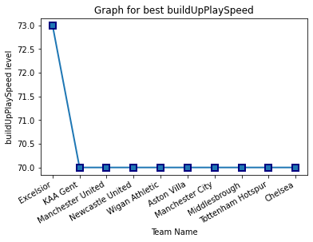

```
GRAPH FOR best buildUpPlayDribbling
```

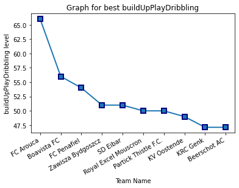

```
GRAPH FOR best buildUpPlayPassing
```

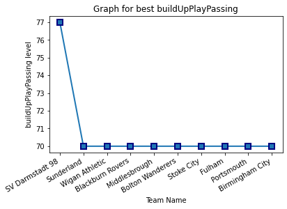

```
GRAPH FOR best chanceCreationPassing
```

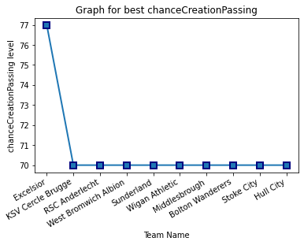

```
GRAPH FOR best chanceCreationCrossing
```

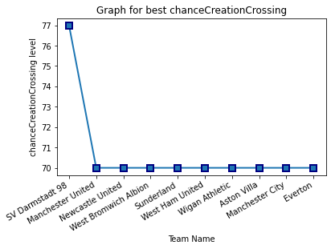

```
GRAPH FOR best chanceCreationShooting
```

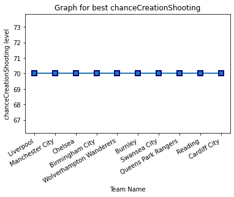

```
GRAPH FOR best defencePressure
```

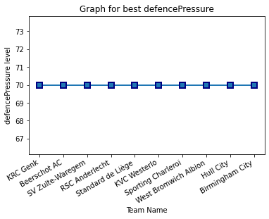

```
GRAPH FOR best defenceAggression
```

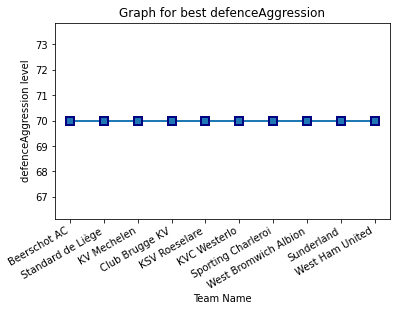

```
[None, None, None, None, None, None, None, None]
```

```python
best_teams_categories = lambda : [plot_best_teams_category(category) for category in df_teams_categories]
best_teams_categories()
```

```python
# Convert date to Age
def age(born):
    born = datetime.strptime(born, '%Y-%m-%d %H:%M:%S').date()
    today = date.today()
    return today.year - born.year - ((today.month,
                                      today.day) < (born.month,
                                                    born.day))
```

```python
# GET AGE OF ALL PLAYERS
birthday = df_players_copy.drop_duplicates(subset=['player_name'], keep='first')
new_birthday = birthday.filter(['player_name','birthday'])
# new_birthday

new_birthday['Age'] = new_birthday['birthday'].apply(age)

display(new_birthday)
```

|  | player_name | birthday | Age |
| --- | --- | --- | --- |
| 0 | Aaron Appindangoye | 1992-02-29 00:00:00 | 30 |
| 5 | Aaron Cresswell | 1989-12-15 00:00:00 | 32 |
| 38 | Aaron Doran | 1991-05-13 00:00:00 | 31 |
| 64 | Aaron Galindo | 1982-05-08 00:00:00 | 40 |
| 87 | Aaron Hughes | 1979-11-08 00:00:00 | 42 |
| ... | ... | ... | ... |
| 183924 | Zoumana Camara | 1979-04-03 00:00:00 | 43 |
| 183937 | Zsolt Laczko | 1986-12-18 00:00:00 | 35 |
| 183953 | Zsolt Low | 1979-04-29 00:00:00 | 43 |
| 183960 | Zurab Khizanishvili | 1981-10-06 00:00:00 | 40 |
| 183968 | Zvjezdan Misimovic | 1982-06-05 00:00:00 | 40 |

10848 rows × 3 columns

```python
# OLDEST PLAYER IN ALL LEAGUES
new_birthday['Age'].max()
```

```
55
```

```python
# YOUNGEST PLAYER IN ALL LEAGUES
new_birthday['Age'].min()
```

```
23
```

```python
# Players based on age group

Under20 = new_birthday[new_birthday['Age'] <=20]
age20_30 = new_birthday[(new_birthday['Age'] >20) & (new_birthday['Age'] <= 30)]
age30_40 = new_birthday[(new_birthday['Age'] >30) & (new_birthday['Age'] <=40)]
Above40 = new_birthday[new_birthday['Age'] > 40]
```

```python
# Under 20
Under20
```

|  | player_name | birthday | Age |
| --- | --- | --- | --- |

```python
# Between 20 and 30
age20_30
```

|  | player_name | birthday | Age |
| --- | --- | --- | --- |
| 0 | Aaron Appindangoye | 1992-02-29 00:00:00 | 30 |
| 139 | Aaron Kuhl | 1996-01-30 00:00:00 | 26 |
| 172 | Aaron Lennox | 1993-02-19 00:00:00 | 29 |
| 309 | Aaron Splaine | 1996-10-13 00:00:00 | 25 |
| 441 | Abdellah Zoubir | 1991-12-05 00:00:00 | 30 |
| ... | ... | ... | ... |
| 183625 | Zinedine Machach | 1996-01-05 00:00:00 | 26 |
| 183634 | Zinho Gano | 1993-10-13 00:00:00 | 28 |
| 183649 | Ziri Hammar | 1992-07-25 00:00:00 | 30 |
| 183660 | Zizo | 1996-01-10 00:00:00 | 26 |
| 183856 | Zoran Josipovic | 1995-08-25 00:00:00 | 26 |

2492 rows × 3 columns

```python
# Between 30 and 40
age30_40
```

|  | player_name | birthday | Age |
| --- | --- | --- | --- |
| 5 | Aaron Cresswell | 1989-12-15 00:00:00 | 32 |
| 38 | Aaron Doran | 1991-05-13 00:00:00 | 31 |
| 64 | Aaron Galindo | 1982-05-08 00:00:00 | 40 |
| 112 | Aaron Hunt | 1986-09-04 00:00:00 | 35 |
| 146 | Aaron Lennon | 1987-04-16 00:00:00 | 35 |
| ... | ... | ... | ... |
| 183895 | Zouhaier Dhaouadhi | 1988-01-01 00:00:00 | 34 |
| 183903 | Zouhair Feddal | 1989-01-01 00:00:00 | 33 |
| 183937 | Zsolt Laczko | 1986-12-18 00:00:00 | 35 |
| 183960 | Zurab Khizanishvili | 1981-10-06 00:00:00 | 40 |
| 183968 | Zvjezdan Misimovic | 1982-06-05 00:00:00 | 40 |

6429 rows × 3 columns

```python
# Above40
Above40
```

|  | player_name | birthday | Age |
| --- | --- | --- | --- |
| 87 | Aaron Hughes | 1979-11-08 00:00:00 | 42 |
| 198 | Aaron Mokoena | 1980-11-25 00:00:00 | 41 |
| 335 | Aaron Wilbraham | 1979-10-21 00:00:00 | 42 |
| 373 | Abasse Ba | 1976-07-12 00:00:00 | 46 |
| 446 | Abdelmajid Oulmers | 1978-09-12 00:00:00 | 43 |
| ... | ... | ... | ... |
| 183564 | Zhi Zheng | 1980-08-20 00:00:00 | 41 |
| 183665 | Zlatan Bajramovic | 1979-08-12 00:00:00 | 42 |
| 183796 | Zoltan Gera | 1979-04-22 00:00:00 | 43 |
| 183924 | Zoumana Camara | 1979-04-03 00:00:00 | 43 |
| 183953 | Zsolt Low | 1979-04-29 00:00:00 | 43 |

1927 rows × 3 columns

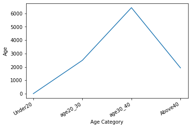

```python
age_category = ["Under20", "age20_30","age30_40", "Above40" ]

age_number = [len(Under20.index), len(age20_30.index),len(age30_40.index), len(Above40.index)]

ages = np.array( age_number)

fig, ax = plt.subplots()
ax.plot(age_category, ages)
fig.autofmt_xdate()
plt.xlabel('Age Category')
plt.ylabel('Age')
plt.show()
```

# GET HOME AND AWAY TOTAL GOALS SCORED

```python
df_home = pd.read_csv('home_team_matches.csv')
df_away = pd.read_csv('away_team_matches.csv')
```

```python
df_home.head()
```

|  | home_team | season | stage | date | home_team_goal |
| --- | --- | --- | --- | --- | --- |
| 0 | KRC Genk | 2008/2009 | 1 | 2008-08-17 00:00:00 | 1 |
| 1 | SV Zulte-Waregem | 2008/2009 | 1 | 2008-08-16 00:00:00 | 0 |
| 2 | KSV Cercle Brugge | 2008/2009 | 1 | 2008-08-16 00:00:00 | 0 |
| 3 | KAA Gent | 2008/2009 | 1 | 2008-08-17 00:00:00 | 5 |
| 4 | FCV Dender EH | 2008/2009 | 1 | 2008-08-16 00:00:00 | 1 |

```python
df_away.head()
```

|  | away_team | season | stage | date | away_team_goal |
| --- | --- | --- | --- | --- | --- |
| 0 | Beerschot AC | 2008/2009 | 1 | 2008-08-17 00:00:00 | 1 |
| 1 | Sporting Lokeren | 2008/2009 | 1 | 2008-08-16 00:00:00 | 0 |
| 2 | RSC Anderlecht | 2008/2009 | 1 | 2008-08-16 00:00:00 | 3 |
| 3 | RAEC Mons | 2008/2009 | 1 | 2008-08-17 00:00:00 | 0 |
| 4 | Standard de Liège | 2008/2009 | 1 | 2008-08-16 00:00:00 | 3 |

```python
# Drop columns from away teams that we do not need and then join the dataframe
df_away.drop(['season', 'stage', 'date'], axis=1, inplace=True)
```

```python
print(df_away.head())
```

```
           away_team  away_team_goal
0       Beerschot AC               1
1   Sporting Lokeren               0
2     RSC Anderlecht               3
3          RAEC Mons               0
4  Standard de Liège               3
```

```python
# Join home and away teams
concantd = df_home.join(df_away)
```

```python
concantd.head()
```

|  | home_team | season | stage | date | home_team_goal | away_team | away_team_goal |
| --- | --- | --- | --- | --- | --- | --- | --- |
| 0 | KRC Genk | 2008/2009 | 1 | 2008-08-17 00:00:00 | 1 | Beerschot AC | 1 |
| 1 | SV Zulte-Waregem | 2008/2009 | 1 | 2008-08-16 00:00:00 | 0 | Sporting Lokeren | 0 |
| 2 | KSV Cercle Brugge | 2008/2009 | 1 | 2008-08-16 00:00:00 | 0 | RSC Anderlecht | 3 |
| 3 | KAA Gent | 2008/2009 | 1 | 2008-08-17 00:00:00 | 5 | RAEC Mons | 0 |
| 4 | FCV Dender EH | 2008/2009 | 1 | 2008-08-16 00:00:00 | 1 | Standard de Liège | 3 |

# HOW DID THE TEAMS FAIR AGAINST EACH OTHER

```python
df_head_to_head = concantd.to_csv('head_to_head_matches.csv')
```

```python
head_to_head = pd.read_csv('head_to_head_matches.csv')
```

```python
head_to_head.describe()
```

|  | Unnamed: 0 | stage | home_team_goal | away_team_goal |
| --- | --- | --- | --- | --- |
| count | 25979.000000 | 25979.000000 | 25979.000000 | 25979.000000 |
| mean | 12989.000000 | 18.242773 | 1.544594 | 1.160938 |
| std | 7499.635658 | 10.407354 | 1.297158 | 1.142110 |
| min | 0.000000 | 1.000000 | 0.000000 | 0.000000 |
| 25% | 6494.500000 | 9.000000 | 1.000000 | 0.000000 |
| 50% | 12989.000000 | 18.000000 | 1.000000 | 1.000000 |
| 75% | 19483.500000 | 27.000000 | 2.000000 | 2.000000 |
| max | 25978.000000 | 38.000000 | 10.000000 | 9.000000 |

```python
# Get total home scored goals
total_home_goals = head_to_head['home_team_goal'].sum()
```

```python
total_home_goals
```

```
40127
```

```python
# Get total away goals
total_away_goals = head_to_head['away_team_goal'].sum()
```

```python
total_away_goals
```

```
30160
```

## GET TEAM'S MOST SCORED GOALS FOR A MATCH

```python
home_head_to_head = pd.read_csv('head_to_head_matches.csv')
max_res = home_head_to_head.groupby('home_team')['home_team_goal'].max().reset_index()
max_res.columns = ['home_team', 'max_goal']
max_res.head()
```

|  | home_team | max_goal |
| --- | --- | --- |
| 0 | 1. FC Kaiserslautern | 5 |
| 1 | 1. FC Köln | 4 |
| 2 | 1. FC Nürnberg | 5 |
| 3 | 1. FSV Mainz 05 | 5 |
| 4 | AC Ajaccio | 3 |

```
             home_team  max_goal
184                PSV        10
211     Real Madrid CF        10
49              Celtic         9
77    FC Bayern Munich         9
262  Tottenham Hotspur         9
51             Chelsea         8
75        FC Barcelona         8
162  Manchester United         8
232         SL Benfica         8
243        Southampton         8
['PSV' 'Real Madrid CF' 'Celtic' 'FC Bayern Munich' 'Tottenham Hotspur'
 'Chelsea' 'FC Barcelona' 'Manchester United' 'SL Benfica' 'Southampton']
[10 10  9  9  9  8  8  8  8  8]
```

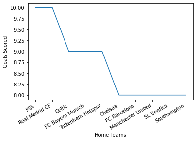

```python
largest_ten= max_res.nlargest(10,'max_goal')
print(largest_ten)
largest_ten_teams = np.array(largest_ten['home_team'])
print(largest_ten_teams)
largest_ten_goals = np.array(largest_ten['max_goal'])
print(largest_ten_goals)
fig, ax = plt.subplots()
ax.plot(largest_ten_teams, largest_ten_goals)
fig.autofmt_xdate()
plt.xlabel('Home Teams')
plt.ylabel('Goals Scored')
plt.show()
```

```python
max_res.to_csv('most_goals_per_team.csv')
```

## GET TEAM'S LESS SCORED GOALS FOR A MATCH

```python
away_head_to_head = pd.read_csv('head_to_head_matches.csv')
min_res = away_head_to_head.groupby('away_team')['away_team_goal'].min().reset_index()
min_res.columns = ['away_team', 'min_goal']
min_res.head()
```

|  | away_team | min_goal |
| --- | --- | --- |
| 0 | 1. FC Kaiserslautern | 0 |
| 1 | 1. FC Köln | 0 |
| 2 | 1. FC Nürnberg | 0 |
| 3 | 1. FSV Mainz 05 | 0 |
| 4 | AC Ajaccio | 0 |

```
              away_team  min_goal
0  1. FC Kaiserslautern         0
1            1. FC Köln         0
2        1. FC Nürnberg         0
3       1. FSV Mainz 05         0
4            AC Ajaccio         0
5      AC Arles-Avignon         0
6         AC Bellinzona         0
7          ADO Den Haag         0
8            AJ Auxerre         0
9             AS Monaco         0
['1. FC Kaiserslautern' '1. FC Köln' '1. FC Nürnberg' '1. FSV Mainz 05'
 'AC Ajaccio' 'AC Arles-Avignon' 'AC Bellinzona' 'ADO Den Haag'
 'AJ Auxerre' 'AS Monaco']
[0 0 0 0 0 0 0 0 0 0]
```

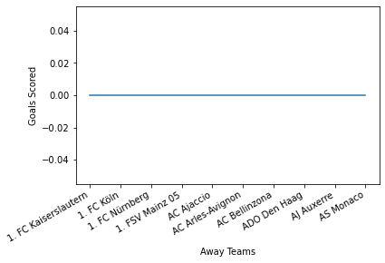

```python
min_ten= min_res.nlargest(10,'min_goal')
print(min_ten)
min_ten_teams = np.array(min_ten['away_team'])
print(min_ten_teams)
min_ten_goals = np.array(min_ten['min_goal'])
print(min_ten_goals)
fig, ax = plt.subplots()
ax.plot(min_ten_teams, min_ten_goals)
fig.autofmt_xdate()
plt.xlabel('Away Teams')
plt.ylabel('Goals Scored')
plt.show()
```

```python
min_res.to_csv('less_goals_per_team.csv')
```

## TEAMS THAT SCORED MOST GOALS

```python
team_max_goals =  pd.read_csv('most_goals_per_team.csv')
```

```python
team_max_goals[team_max_goals.max_goal == team_max_goals.max_goal.max()]
```

|  | Unnamed: 0 | home_team | max_goal |
| --- | --- | --- | --- |
| 184 | 184 | PSV | 10 |
| 211 | 211 | Real Madrid CF | 10 |

## TEAMS THAT SCORED LESS GOALS

```python
team_min_goals =  pd.read_csv('less_goals_per_team.csv')
```

```python
team_min_goals[team_min_goals.min_goal == team_min_goals.min_goal.min()]
```

|  | Unnamed: 0 | away_team | min_goal |
| --- | --- | --- | --- |
| 0 | 0 | 1. FC Kaiserslautern | 0 |
| 1 | 1 | 1. FC Köln | 0 |
| 2 | 2 | 1. FC Nürnberg | 0 |
| 3 | 3 | 1. FSV Mainz 05 | 0 |
| 4 | 4 | AC Ajaccio | 0 |
| ... | ... | ... | ... |
| 291 | 291 | Xerez Club Deportivo | 0 |
| 292 | 292 | Zagłębie Lubin | 0 |
| 293 | 293 | Zawisza Bydgoszcz | 0 |
| 294 | 294 | Évian Thonon Gaillard FC | 0 |
| 295 | 295 | Śląsk Wrocław | 0 |

296 rows × 3 columns

## MATCHES WHERE HOME TEAMS WON(AWAY TEAMS THAT LOST)

```python
home_win_head_to_head = pd.read_csv('head_to_head_matches.csv')
teams_won = home_win_head_to_head[home_win_head_to_head['home_team_goal'] > home_win_head_to_head['away_team_goal']]
print(teams_won[teams_won.columns[0]].count())
teams_won.head()
```

```
11917
```

|  | Unnamed: 0 | home_team | season | stage | date | home_team_goal | away_team | away_team_goal |
| --- | --- | --- | --- | --- | --- | --- | --- | --- |
| 3 | 3 | KAA Gent | 2008/2009 | 1 | 2008-08-17 00:00:00 | 5 | RAEC Mons | 0 |
| 8 | 8 | KVC Westerlo | 2008/2009 | 1 | 2008-08-16 00:00:00 | 1 | Sporting Charleroi | 0 |
| 9 | 9 | Club Brugge KV | 2008/2009 | 10 | 2008-11-01 00:00:00 | 4 | KV Kortrijk | 1 |
| 21 | 21 | KSV Cercle Brugge | 2008/2009 | 11 | 2008-11-07 00:00:00 | 2 | SV Zulte-Waregem | 0 |
| 25 | 25 | KVC Westerlo | 2008/2009 | 11 | 2008-11-08 00:00:00 | 1 | KRC Genk | 0 |

```python
teams_won.to_csv('win_teams.csv')
```

## MATCHES WHERE HOME TEAMS LOST(AWAY TEAMS THAT WON)

```python
away_win_head_to_head = pd.read_csv('head_to_head_matches.csv')
teams_lost = away_win_head_to_head[away_win_head_to_head['home_team_goal'] < away_win_head_to_head['away_team_goal']]
print(teams_lost[teams_lost.columns[0]].count())
teams_lost.head()
```

```
7466
```

|  | Unnamed: 0 | home_team | season | stage | date | home_team_goal | away_team | away_team_goal |
| --- | --- | --- | --- | --- | --- | --- | --- | --- |
| 2 | 2 | KSV Cercle Brugge | 2008/2009 | 1 | 2008-08-16 00:00:00 | 0 | RSC Anderlecht | 3 |
| 4 | 4 | FCV Dender EH | 2008/2009 | 1 | 2008-08-16 00:00:00 | 1 | Standard de Liège | 3 |
| 7 | 7 | Tubize | 2008/2009 | 1 | 2008-08-16 00:00:00 | 1 | Royal Excel Mouscron | 2 |
| 10 | 10 | Standard de Liège | 2008/2009 | 10 | 2008-10-31 00:00:00 | 1 | Sporting Charleroi | 2 |
| 11 | 11 | SV Zulte-Waregem | 2008/2009 | 10 | 2008-11-02 00:00:00 | 0 | KAA Gent | 2 |

```python
teams_lost.to_csv('loss_teams.csv')
```

## TEAMS THAT DREW(NO TEAM WON)

```python
draw_head_to_head = pd.read_csv('head_to_head_matches.csv')
teams_draw = draw_head_to_head[draw_head_to_head['home_team_goal'] == draw_head_to_head['away_team_goal']]
print(teams_draw[teams_draw.columns[0]].count())
teams_draw.head()
```

```
6596
```

|  | Unnamed: 0 | home_team | season | stage | date | home_team_goal | away_team | away_team_goal |
| --- | --- | --- | --- | --- | --- | --- | --- | --- |
| 0 | 0 | KRC Genk | 2008/2009 | 1 | 2008-08-17 00:00:00 | 1 | Beerschot AC | 1 |
| 1 | 1 | SV Zulte-Waregem | 2008/2009 | 1 | 2008-08-16 00:00:00 | 0 | Sporting Lokeren | 0 |
| 5 | 5 | KV Mechelen | 2008/2009 | 1 | 2008-09-24 00:00:00 | 1 | Club Brugge KV | 1 |
| 6 | 6 | KSV Roeselare | 2008/2009 | 1 | 2008-08-16 00:00:00 | 2 | KV Kortrijk | 2 |
| 12 | 12 | Sporting Lokeren | 2008/2009 | 10 | 2008-11-01 00:00:00 | 0 | RAEC Mons | 0 |

```python
teams_draw.to_csv('draw_teams.csv')
```

## HOME TEAM SEASONAL PERFORMANCE

```python
season_head_to_head = pd.read_csv('head_to_head_matches.csv')
home_teams_per_season_max = season_head_to_head.groupby(['home_team', 'season'])['home_team_goal'].max().reset_index()
home_teams_per_season_min = season_head_to_head.groupby(['home_team', 'season'])['home_team_goal'].min().reset_index()
print(home_teams_per_season_max.head())
home_teams_per_season_min.head()
```

```
              home_team     season  home_team_goal
0  1. FC Kaiserslautern  2010/2011               5
1  1. FC Kaiserslautern  2011/2012               3
2            1. FC Köln  2008/2009               2
3            1. FC Köln  2009/2010               3
4            1. FC Köln  2010/2011               4
```

|  | home_team | season | home_team_goal |
| --- | --- | --- | --- |
| 0 | 1. FC Kaiserslautern | 2010/2011 | 0 |
| 1 | 1. FC Kaiserslautern | 2011/2012 | 0 |
| 2 | 1. FC Köln | 2008/2009 | 0 |
| 3 | 1. FC Köln | 2009/2010 | 0 |
| 4 | 1. FC Köln | 2010/2011 | 0 |

## AWAY TEAM SEASONAL PERFORMANCE

```python
season_away_head_to_head = pd.read_csv('head_to_head_matches.csv')
away_teams_per_season_max = season_away_head_to_head.groupby(['away_team', 'season'])['away_team_goal'].max().reset_index()
away_teams_per_season_min = season_away_head_to_head.groupby(['away_team', 'season'])['away_team_goal'].min().reset_index()
print(away_teams_per_season_max.head())
print(away_teams_per_season_min.head())
```

```
              away_team     season  away_team_goal
0  1. FC Kaiserslautern  2010/2011               4
1  1. FC Kaiserslautern  2011/2012               2
2            1. FC Köln  2008/2009               3
3            1. FC Köln  2009/2010               4
4            1. FC Köln  2010/2011               2
              away_team     season  away_team_goal
0  1. FC Kaiserslautern  2010/2011               0
1  1. FC Kaiserslautern  2011/2012               0
2            1. FC Köln  2008/2009               0
3            1. FC Köln  2009/2010               0
4            1. FC Köln  2010/2011               0
```

# TEAMS THAT PLAYED EACH OTHER SEASONALY

## HOME TEAM SEASONAL PERFORMANCE

```python
#Club's seasonal games against other teams
home_season_head_to_head = pd.read_csv('head_to_head_matches.csv')
seasonal_games = home_season_head_to_head.groupby(['home_team', 'away_team', 'season', 'home_team_goal', 'away_team_goal'])['home_team_goal', 'away_team_goal'].apply(list)
print(seasonal_games.head())
seasonal_games.to_csv('seasonal_games.csv')
```

```
home_team             away_team        season     home_team_goal  away_team_goal
1. FC Kaiserslautern  1. FC Köln       2010/2011  1               1                 [home_team_goal, away_team_goal]
                                       2011/2012  0               1                 [home_team_goal, away_team_goal]
                      1. FC Nürnberg   2010/2011  0               2                 [home_team_goal, away_team_goal]
                                       2011/2012  0               2                 [home_team_goal, away_team_goal]
                      1. FSV Mainz 05  2010/2011  0               1                 [home_team_goal, away_team_goal]
dtype: object
```

```python
# CLub's summary home and way basing on season and totals
away_season_head_to_head = pd.read_csv('head_to_head_matches.csv')
home_seasonal_games = away_season_head_to_head.groupby(['home_team', 'season'])['home_team_goal'].sum().reset_index(name='total_home_goals')
away_seasonal_games = away_season_head_to_head.groupby(['away_team', 'season'])['away_team_goal'].sum().reset_index(name='total_away_goals')
print(home_seasonal_games.head())
print(away_seasonal_games.head())
```

```
              home_team     season  total_home_goals
0  1. FC Kaiserslautern  2010/2011                25
1  1. FC Kaiserslautern  2011/2012                12
2            1. FC Köln  2008/2009                14
3            1. FC Köln  2009/2010                18
4            1. FC Köln  2010/2011                30
              away_team     season  total_away_goals
0  1. FC Kaiserslautern  2010/2011                23
1  1. FC Kaiserslautern  2011/2012                12
2            1. FC Köln  2008/2009                21
3            1. FC Köln  2009/2010                15
4            1. FC Köln  2010/2011                17
```

## TOTAL GOALS PER SEASON FOR EACH CLUB

```python
home_seasonal_games['TotalGoals'] = home_seasonal_games['total_home_goals'] + away_seasonal_games['total_away_goals']
print(home_seasonal_games.head())
home_seasonal_games.to_csv('total_goals_per_season.csv')
```

```
              home_team     season  total_home_goals  TotalGoals
0  1. FC Kaiserslautern  2010/2011                25          48
1  1. FC Kaiserslautern  2011/2012                12          24
2            1. FC Köln  2008/2009                14          35
3            1. FC Köln  2009/2010                18          33
4            1. FC Köln  2010/2011                30          47
```

```python
# MAXIMUM GOALS SCORED BY A TEAM IN ALL SEASONS
maxim_goals = pd.read_csv('total_goals_per_season.csv')
print(maxim_goals.describe())
maxim_goals_scored = maxim_goals['TotalGoals'].max()
maxim_goals_scored
```

```
        Unnamed: 0  total_home_goals   TotalGoals
count  1478.000000       1478.000000  1478.000000
mean    738.500000         27.149526    47.555480
std     426.806162          9.681661    15.895455
min       0.000000          3.000000     5.000000
25%     369.250000         21.000000    37.000000
50%     738.500000         25.000000    45.000000
75%    1107.750000         32.000000    55.000000
max    1477.000000         73.000000   121.000000
```

```
121
```

### WHICH TEAM SCORED MOST GOALS

```python
# Team with most goals
maxim_goals[maxim_goals['TotalGoals'] == maxim_goals['TotalGoals'].max()]
```

|  | Unnamed: 0 | home_team | season | total_home_goals | TotalGoals |
| --- | --- | --- | --- | --- | --- |
| 1047 | 1047 | Real Madrid CF | 2011/2012 | 70 | 121 |

# WHAT TEAM SCORED MOST HOME GOALS

```python
# Team with most home goals
maxim_goals[maxim_goals['total_home_goals'] == maxim_goals['total_home_goals'].max()]
```

|  | Unnamed: 0 | home_team | season | total_home_goals | TotalGoals |
| --- | --- | --- | --- | --- | --- |
| 352 | 352 | FC Barcelona | 2011/2012 | 73 | 114 |

### HOW MANY AND WHAT CATEGORIES FOR SEASONS ARE THERE?

```python
season_categories = pd.read_csv('head_to_head_matches.csv')
categories = season_categories['season'].astype('category')
categories
```

```
0        2008/2009
1        2008/2009
2        2008/2009
3        2008/2009
4        2008/2009
           ...
25974    2015/2016
25975    2015/2016
25976    2015/2016
25977    2015/2016
25978    2015/2016
Name: season, Length: 25979, dtype: category
Categories (8, object): ['2008/2009', '2009/2010', '2010/2011', '2011/2012', '2012/2013', '2013/2014', '2014/2015', '2015/2016']
```

### HOW MANY AND WHAT CATEGORIES FOR STAGES ARE THERE?

```python
stage_categories = pd.read_csv('head_to_head_matches.csv')
categories = stage_categories['stage'].astype('category')
categories
```

```
0        1
1        1
2        1
3        1
4        1
        ..
25974    9
25975    9
25976    9
25977    9
25978    9
Name: stage, Length: 25979, dtype: category
Categories (38, int64): [1, 2, 3, 4, ..., 35, 36, 37, 38]
```

# CONCLUSION

## LIMITATIONS

1. **There was no way to determine the relationship between players and goals scored. I would suggest the dataset to show who scored for what team.**
2. **Other factors that determine a team winning or loosing like red cards are missing.**